# Tarea Examen 1 - Aprendizaje Estadístico Automatizado

### e)

Podemos construir un modelo con interacciones entre las variables predictoras.

Una opción es incluir la interacción entre el año del modelo del auto y el lugar de origen

```r
#Interacción entre year:origin
modelos[[2]] <- lm(mpg ~ cylinders + displacement + horsepower + weight + acceleration + year + origin + year:origin, data = Auto)
summary(modelos[[2]])
```

```
##
## Call:
## lm(formula = mpg ~ cylinders + displacement + horsepower + weight +
##     acceleration + year + origin + year:origin, data = Auto)
##
## Residuals:
##     Min      1Q  Median      3Q     Max
## -8.6971 -1.7959 -0.0851  1.3937 12.7589
##
## Coefficients:
##                Estimate Std. Error t value Pr(>|t|)
## (Intercept)  -7.671e+00  5.437e+00  -1.411  0.15908
## cylinders4    6.661e+00  1.617e+00   4.121 4.64e-05 ***
## cylinders5    5.735e+00  2.466e+00   2.326  0.02055 *
## cylinders6    3.131e+00  1.781e+00   1.758  0.07960 .
## cylinders8    4.928e+00  2.056e+00   2.397  0.01700 *
## displacement  1.381e-02  7.120e-03   1.940  0.05316 .
## horsepower   -3.387e-02  1.290e-02  -2.627  0.00898 **
## weight       -5.601e-03  6.157e-04  -9.098  < 2e-16 ***
## acceleration  1.871e-02  9.090e-02   0.206  0.83699
## year          5.562e-01  6.202e-02   8.970  < 2e-16 ***
## origin2      -4.156e+01  9.677e+00  -4.295 2.22e-05 ***
## origin3      -2.315e+01  8.806e+00  -2.629  0.00891 **
## year:origin2  5.663e-01  1.267e-01   4.470 1.04e-05 ***
## year:origin3  3.301e-01  1.130e-01   2.922  0.00369 **
## ---
## Signif. codes:  0 '***' 0.001 '**' 0.01 '*' 0.05 '.' 0.1 ' ' 1
##
## Residual standard error: 3.015 on 378 degrees of freedom
## Multiple R-squared:  0.8558, Adjusted R-squared:  0.8508
## F-statistic: 172.5 on 13 and 378 DF,  p-value: < 2.2e-16
```

```r
anova(modelos[[1]],modelos[[2]])
```

```
## Analysis of Variance Table
##
## Model 1: mpg ~ cylinders + displacement + horsepower + weight + acceleration +
##     year + origin
## Model 2: mpg ~ cylinders + displacement + horsepower + weight + acceleration +
##     year + origin + year:origin
##   Res.Df    RSS Df Sum of Sq      F    Pr(>F)
## 1    380 3646.3
## 2    378 3435.4  2    210.94 11.605 1.284e-05 ***
## ---
## Signif. codes:  0 '***' 0.001 '**' 0.01 '*' 0.05 '.' 0.1 ' ' 1
```

Otra opción es incluir la interacción entre el peso y la aceleración en el primer modelo (el que tiene todas las variables predictoras)

```r
#Interacción weight:acceleration
modelos[[3]] <- lm(mpg ~ cylinders + displacement + horsepower + weight + acceleration + weight:acceleration + year + origin, data = Auto)
summary(modelos[[3]])
```

```
##
## Call:
## lm(formula = mpg ~ cylinders + displacement + horsepower + weight +
##     acceleration + weight:acceleration + year + origin, data = Auto)
##
## Residuals:
##     Min      1Q  Median      3Q     Max
## -7.9994 -1.9358 -0.0442  1.4969 12.2548
##
## Coefficients:
##                       Estimate Std. Error t value Pr(>|t|)
## (Intercept)         -4.094e+01  5.907e+00  -6.930 1.82e-11 ***
## cylinders4           6.331e+00  1.610e+00   3.933 9.98e-05 ***
## cylinders5           7.286e+00  2.447e+00   2.978 0.003089 **
## cylinders6           4.036e+00  1.779e+00   2.268 0.023881 *
## cylinders8           5.226e+00  2.050e+00   2.549 0.011205 *
## displacement         7.072e-03  7.427e-03   0.952 0.341613
## horsepower          -4.653e-02  1.308e-02  -3.557 0.000423 ***
## weight               1.634e-03  1.661e-03   0.984 0.325948
## acceleration         1.146e+00  2.501e-01   4.582 6.25e-06 ***
## year                 7.639e-01  4.789e-02  15.951  < 2e-16 ***
## origin2              1.531e+00  5.381e-01   2.846 0.004671 **
## origin3              2.174e+00  5.208e-01   4.174 3.72e-05 ***
## weight:acceleration -4.206e-04  8.756e-05  -4.804 2.25e-06 ***
## ---
## Signif. codes:  0 '***' 0.001 '**' 0.01 '*' 0.05 '.' 0.1 ' ' 1
##
## Residual standard error: 3.011 on 379 degrees of freedom
## Multiple R-squared:  0.8557, Adjusted R-squared:  0.8511
## F-statistic: 187.3 on 12 and 379 DF,  p-value: < 2.2e-16
```

También podríamos tomar en cuenta la interacción entre el número de cilindros y el volúmen útil de todos los cilindros pues hay una clara relación entre ambas variables predictoras.

```r
#Interacción cylinders:displacement
modelos[[4]] <- lm(mpg ~ cylinders + displacement + cylinders:displacement + horsepower + weight + acceleration + year + origin, data = Auto)
summary(modelos[[4]])
```

```
##
## Call:
## lm(formula = mpg ~ cylinders + displacement + cylinders:displacement +
##     horsepower + weight + acceleration + year + origin, data = Auto)
##
## Residuals:
##     Min      1Q  Median      3Q     Max
## -7.2034 -1.6796 -0.1332  1.4245 12.2552
##
## Coefficients:
##                           Estimate Std. Error t value Pr(>|t|)
## (Intercept)             -3.826e+01  2.448e+01  -1.563 0.118947
## cylinders4               2.995e+01  2.432e+01   1.231 0.218923
## cylinders5               2.847e+01  2.597e+01   1.096 0.273704
## cylinders6               1.943e+01  2.446e+01   0.794 0.427627
## cylinders8               9.043e+00  2.444e+01   0.370 0.711621
## displacement             2.074e-01  3.353e-01   0.619 0.536580
## horsepower              -4.716e-02  1.329e-02  -3.547 0.000438 ***
## weight                  -3.807e-03  6.453e-04  -5.900 8.12e-09 ***
## acceleration            -8.600e-02  8.871e-02  -0.969 0.332956
## year                     7.647e-01  4.676e-02  16.352  < 2e-16 ***
## origin2                  2.603e-01  5.523e-01   0.471 0.637656
## origin3                  9.897e-01  5.377e-01   1.841 0.066474 .
## cylinders4:displacement -2.789e-01  3.349e-01  -0.833 0.405454
## cylinders5:displacement -2.503e-01  3.406e-01  -0.735 0.462948
## cylinders6:displacement -2.119e-01  3.353e-01  -0.632 0.527854
## cylinders8:displacement -1.729e-01  3.351e-01  -0.516 0.606176
## ---
## Signif. codes:  0 '***' 0.001 '**' 0.01 '*' 0.05 '.' 0.1 ' ' 1
##
## Residual standard error: 2.894 on 376 degrees of freedom
## Multiple R-squared:  0.8678, Adjusted R-squared:  0.8626
## F-statistic: 164.6 on 15 and 376 DF,  p-value: < 2.2e-16
```

Por último, podemos crear un modelo que tome en cuenta las dos interacciones anteriores, los cilíndros con el el volumen útil y el peso con la aceleración.

```r
#Interacción weight:acceleration y cylinders:displacement
modelos[[5]] <- lm(mpg ~ cylinders + displacement + cylinders:displacement + horsepower + weight + acceleration + weight:acceleration + year + origin, data = Auto)
summary(modelos[[5]])
```

```
##
## Call:
## lm(formula = mpg ~ cylinders + displacement + cylinders:displacement +
##     horsepower + weight + acceleration + weight:acceleration +
##     year + origin, data = Auto)
##
## Residuals:
##     Min      1Q  Median      3Q     Max
## -7.2765 -1.7176 -0.1686  1.4047 12.0933
##
## Coefficients:
##                           Estimate Std. Error t value Pr(>|t|)
## (Intercept)             -4.341e+01  2.476e+01  -1.753 0.080373 .
## cylinders4               2.809e+01  2.434e+01   1.154 0.249091
## cylinders5               2.627e+01  2.600e+01   1.010 0.313010
## cylinders6               1.774e+01  2.447e+01   0.725 0.468917
## cylinders8               9.522e+00  2.442e+01   0.390 0.696828
## displacement             1.899e-01  3.352e-01   0.567 0.571323
## horsepower              -4.789e-02  1.329e-02  -3.603 0.000357 ***
## weight                  -1.635e-03  1.756e-03  -0.931 0.352261
## acceleration             2.797e-01  2.889e-01   0.968 0.333656
## year                     7.737e-01  4.721e-02  16.390  < 2e-16 ***
## origin2                  3.495e-01  5.558e-01   0.629 0.529851
## origin3                  1.017e+00  5.376e-01   1.892 0.059219 .
## cylinders4:displacement -2.577e-01  3.349e-01  -0.770 0.442045
## cylinders5:displacement -2.267e-01  3.407e-01  -0.665 0.506245
## cylinders6:displacement -1.927e-01  3.353e-01  -0.575 0.565798
## cylinders8:displacement -1.623e-01  3.348e-01  -0.485 0.628084
## weight:acceleration     -1.343e-04  1.010e-04  -1.330 0.184412
## ---
## Signif. codes:  0 '***' 0.001 '**' 0.01 '*' 0.05 '.' 0.1 ' ' 1
##
## Residual standard error: 2.891 on 375 degrees of freedom
## Multiple R-squared:  0.8685, Adjusted R-squared:  0.8628
## F-statistic: 154.7 on 16 and 375 DF,  p-value: < 2.2e-16
```

Para comparar los modelos nos fijarnos en las gráficas de los residuales

```r
for (i in 1:5) {
print(summary(modelos[[i]])$r.square)
}
```

```
## [1] 0.8469157
## [1] 0.8557717
## [1] 0.855701
## [1] 0.8678361
## [1] 0.8684563
```

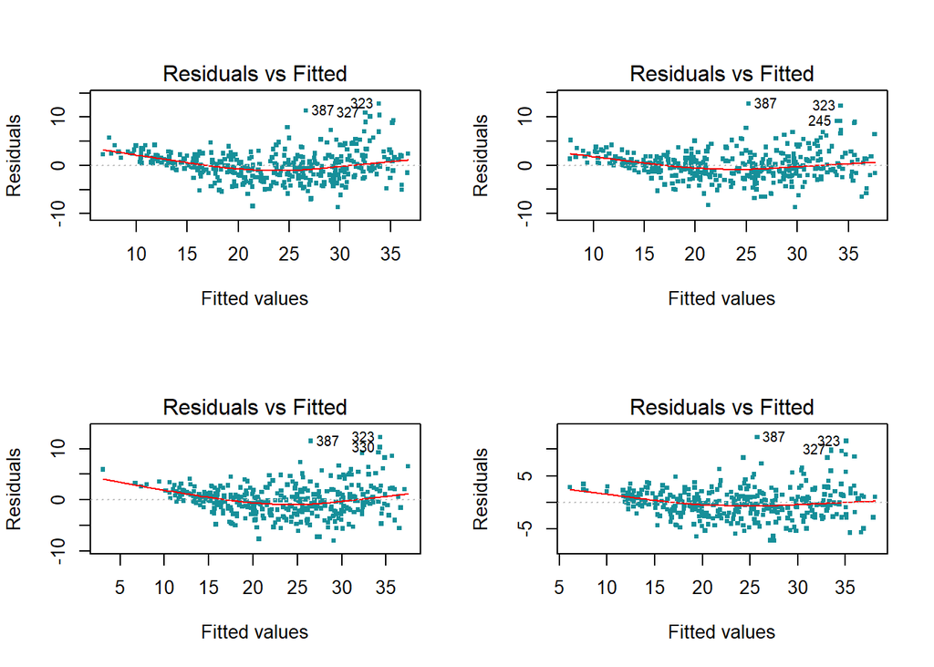

```r
par(mfrow = c(2,2))
plot(modelos[[1]], which = 1, pch = '.', cex = 4, col="#168f99")
plot(modelos[[2]], which = 1, pch = '.', cex = 4, col="#168f99")
plot(modelos[[3]], which = 1, pch = '.', cex = 4, col="#168f99")
plot(modelos[[4]], which = 1, pch = '.', cex = 4, col="#168f99")
```